# Processing Fees

CP

March 9, 2018

## 1: SUMMARY

- As % of **Processed Revenues** slight *overall increase*, but the **Chargeback** and **Failed fees** remained constant;
- Historically over **two FY** there is a significant *increase* in the *number of **Chargeback transactions** from **mobile** devices;

## 2: Share of REVENUES

Processing fees by **Transaction Type** as percentage of *overall* **Processed REVENUES** (cc SALES+REBILLS)

- Overall increase of *transaction fees* to **7.4%**, mainly on **mobile** and **unidentified** device types;
- **Chargeback** fees remained flat from JAN at **1.4%**;
- **Failed** transaction fees remained flat at the lowest level over *two fiscal years*

### OVERALL

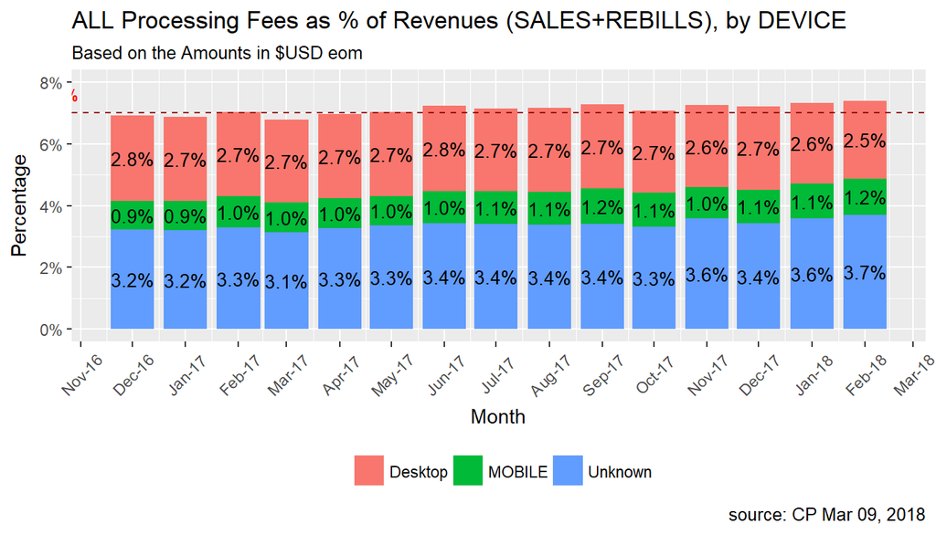

### SALES

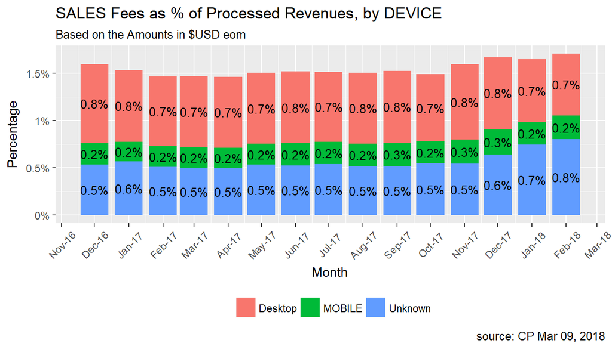

### REBILLS

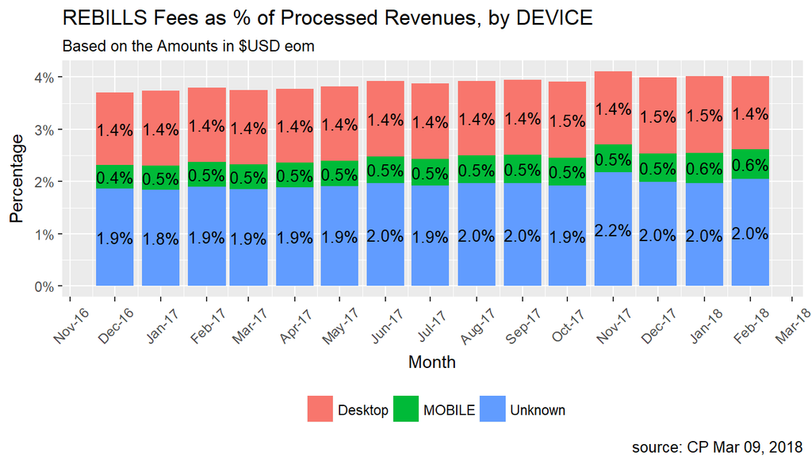

### CHARGEBACKS

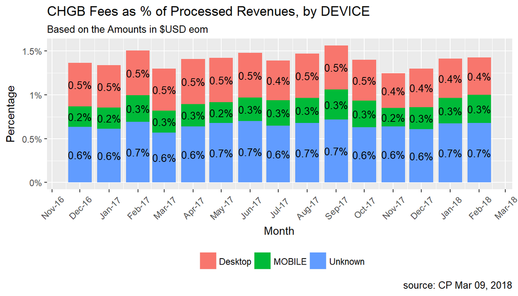

### REFUNDS

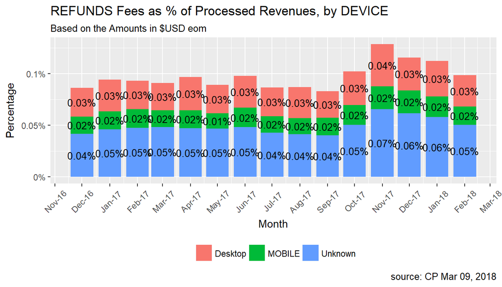

### FAILED

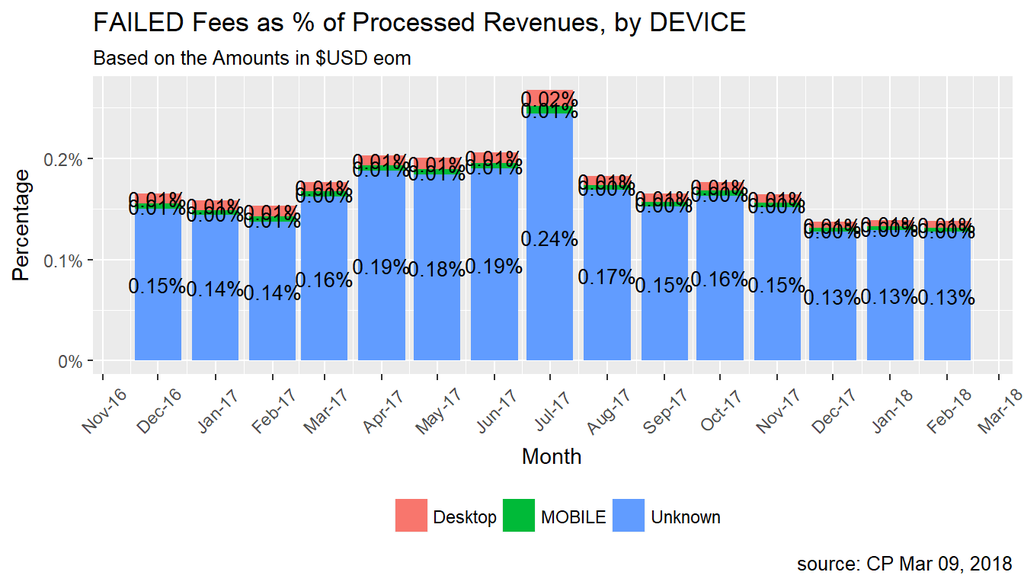

## 3: CHARGEBACKS Analysis

- Compared to FEB of **previous FY** there is no significant change in the number of average daily chargebacks, regardless of the **device type**. However, for **desktop** and **unknown** platforms the numbers are more likely to *decline* ;
- Historically over **two FY** there is a significant *increase* in the *number of transactions* from **mobile** devices;

### YoY COUNT

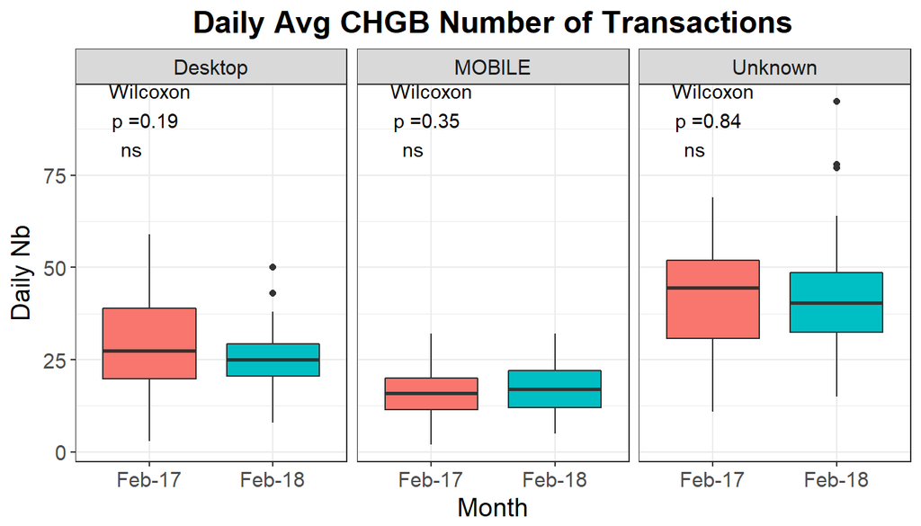

### FY17-FY18 COUNT

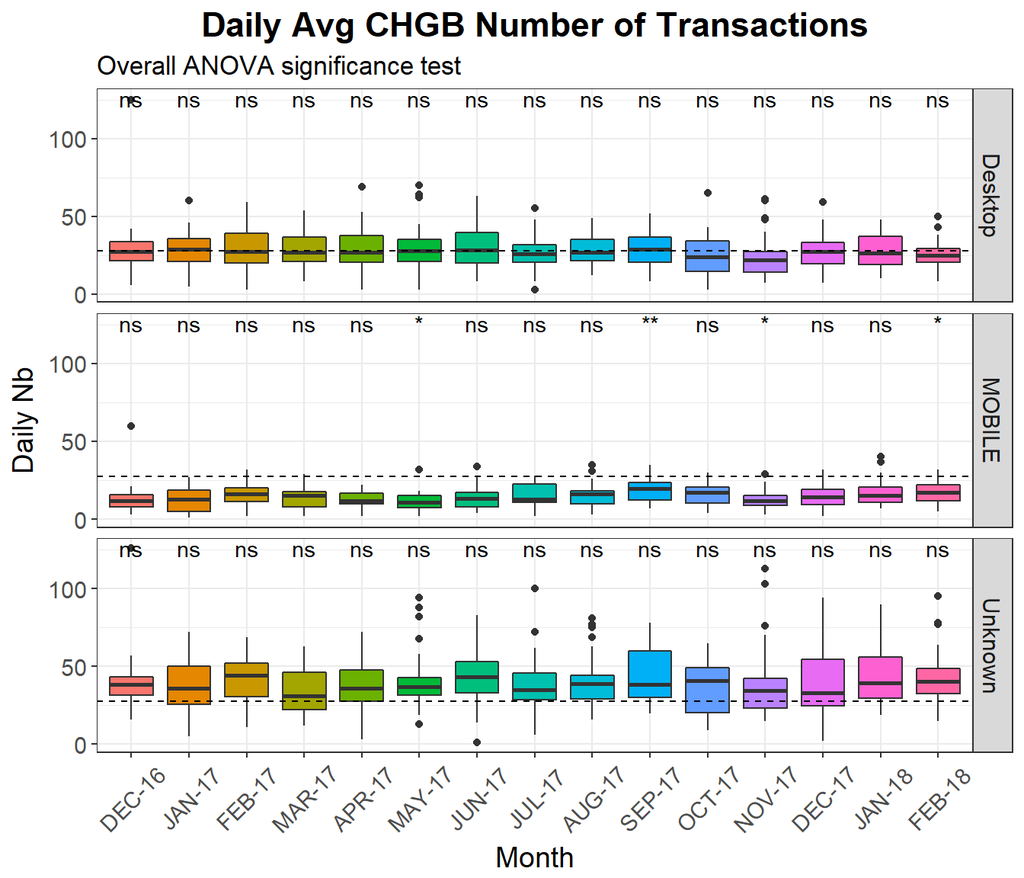

### YoY AMOUNTS

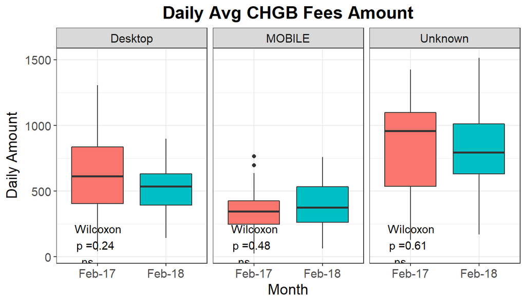

## 4: REFUNDS Analysis

- Compared to FEB of **previous FY** there is no significant change in the number of average daily chargebacks, regardless of the **device type**. However, for **all device types** the transaction numbers are more likely to *increase* ;
- Historically over **two FY** for **all device types** there is *no significant change* in the *number of transactions* for the current period;

### YoY COUNT

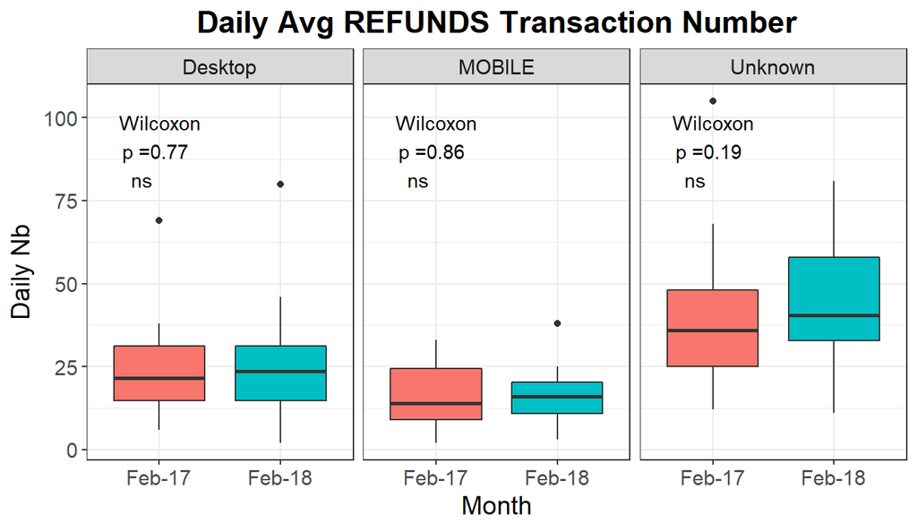

### FY17-FY18 COUNT

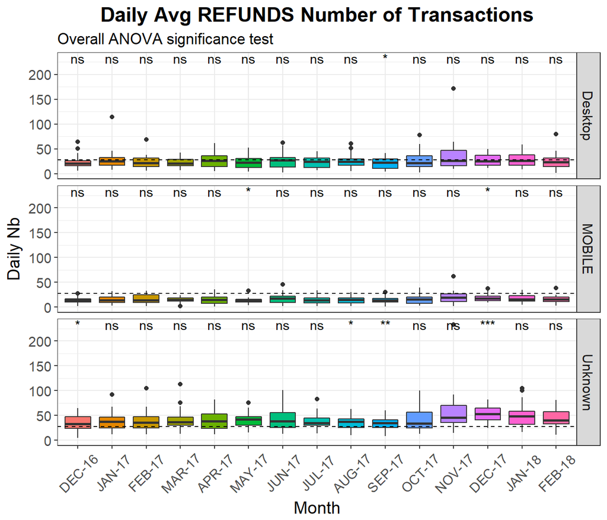

### YoY AMOUNTS

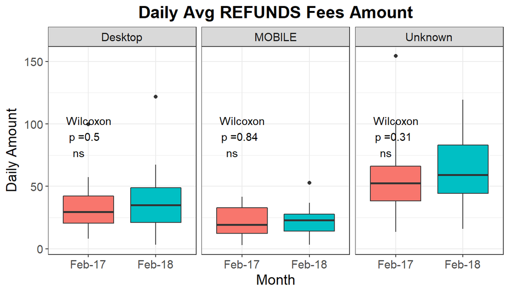

## 5: Share by Device

Share of **Transaction Fees** by **Device Type**, for each **Transaction Type**

### SALES

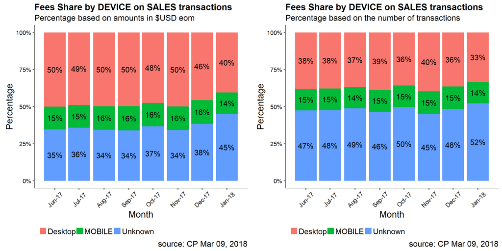

### REBILLS

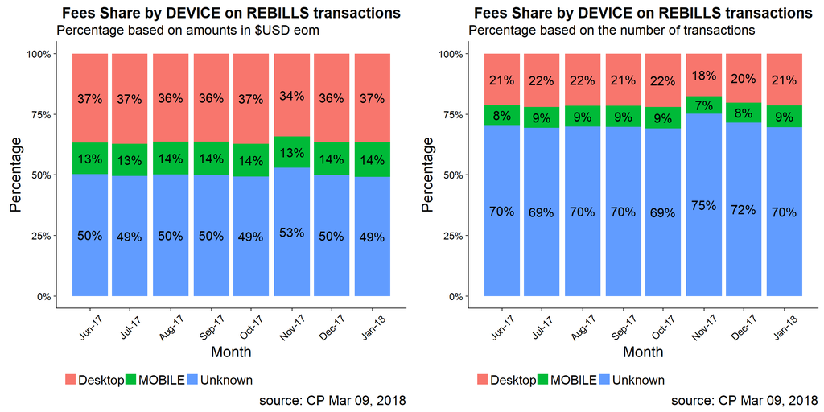

### CHARGEBACKS

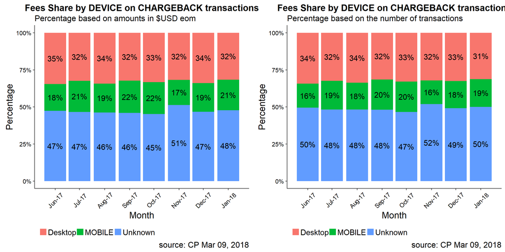

### REFUNDS

[figure not shown]

### FAILED

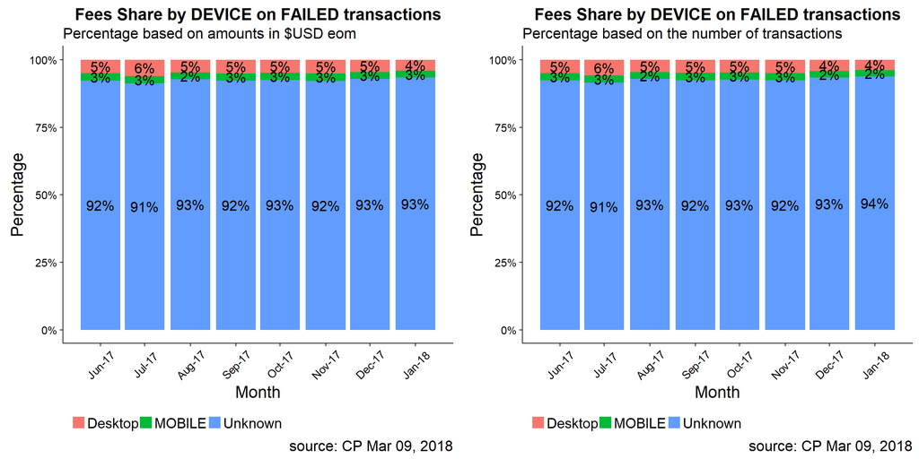